## STAT 689 Homework 6

### Rohan Tiwari

The Framingham Heart Study https://www.framinghamheartstudy.org/ is the longest on-going study of risk factors from heart disease and many other types of chronic diseases. It is a national treasure started in 1948.This exercise is to study whether systolic blood pressure and serum cholesterol are related, and whether smoking status (and later on age) are factors in systolic blood pressure (it is). Later, instead of having a continuous response, we will have a binary response, namely coronary heart disease.

```r
setwd("~/tamu/MS-STAT-2022/689-flexible-regression")
framingham = read.csv("framingham.csv")
head(framingham)
```

```
##   OBS Age SBP21 SBP22 SBP31 SBP32 Smoker Cholest2 Cholest3 CHD
## 1   1  56   110   120   136   134      0      276      295   0
## 2   2  38   118   126   120   114      1      211      255   0
## 3   3  54   140   120   125   124      1      284      287   0
## 4   4  42   122   116   115   110      1      225      285   0
## 5   5  47   136   134   130   144      1      292      240   0
## 6   6  43   138   120   118   110      1      192      208   0
```

There are four systolic blood pressure measurements. Take their average and create the variable LSBP = log(SBP-50). This is a normalizing transformation that makes the histogram look better. Also, take the average the two cholesterol measurements and take their logarithm, calling it Lcholest.

```r
framingham$LSBP = log(apply(framingham[,c("SBP22" , "SBP21" ,"SBP31" ,"SBP32")], 1,mean) - 50)
framingham$Lcholest = log(apply(framingham[,c("Cholest2" , "Cholest3" )], 1,mean))
```

### 1. Fit a multiple linear regression of LSBP (Y) on Lcholest and smoker using lm. Since the smoking variable is binary, this is an ordinary ANCOVA without an interaction. You will notice that the Rsquared is quite low. Produce a table of estimates, standard errors and p-values.

```r
framingham.model.mlr = lm (LSBP ~ Lcholest + Smoker, data = framingham)
summary(framingham.model.mlr)
```

```
##
## Call:
## lm(formula = LSBP ~ Lcholest + Smoker, data = framingham)
##
## Residuals:
##      Min       1Q   Median       3Q      Max
## -0.79148 -0.14009 -0.02043  0.10915  0.93289
##
## Coefficients:
##             Estimate Std. Error t value Pr(>|t|)
## (Intercept)  3.55569    0.17029  20.880  < 2e-16 ***
## Lcholest     0.15540    0.03140   4.949 8.22e-07 ***
## Smoker      -0.03796    0.01251  -3.034  0.00246 **
## ---
## Signif. codes:  0 '***' 0.001 '**' 0.01 '*' 0.05 '.' 0.1 ' ' 1
##
## Residual standard error: 0.2107 on 1612 degrees of freedom
## Multiple R-squared:  0.02036,    Adjusted R-squared:  0.01915
## F-statistic: 16.75 on 2 and 1612 DF,  p-value: 6.299e-08
```

### 2. Just for fun (not graded) Do a little bit of a web search about whether smokers have higher or lower blood pressure than nonsmokers. Does the analysis in (1) agree?

As per the model in (1), the slope of smoker is negative. This means that for each 1 unit increase in smoking level i.e. when it’s value goes from 0 to 1, the LSBP decreases by roughly 0.03796 on average.

A quick online search(https://www.ahajournals.org/doi/10.1161/01.HYP.37.2.187#:~:text=Smoking%20causes%20an%20acute%20increase,be%20associated%20with%20malignant%20hypertension.&text=Nicotine%20acts%20as%20an%20adrenergic,possibly%20the%20release%20of%20vasopressin.) suggests that smoking causes increase in blood pressure which does not agree with our model in (1).

### 3. In Question 1, there is a subtle statistical interpretation of what I am asking you to do, because your analysis also includes the transformed cholesterol variable. I am curious if you can produce the correct terminology for what that subtle interpretation is. Please, less than 15 words. This is a test of your background, but I want to make sure you know how to report results appropriately.

Expected value of LSBP conditional on Lcholest holding smoking status to certain value

### 4. Do the same thing as in Question 1 but add an interaction

```r
framingham.model.mlr.int = lm (LSBP ~ Lcholest + Smoker + Lcholest : Smoker, data = framingham)
summary(framingham.model.mlr.int)
```

```
##
## Call:
## lm(formula = LSBP ~ Lcholest + Smoker + Lcholest:Smoker, data = framingham)
##
## Residuals:
##      Min       1Q   Median       3Q      Max
## -0.79151 -0.14039 -0.02046  0.10916  0.93280
##
## Coefficients:
##                 Estimate Std. Error t value Pr(>|t|)
## (Intercept)      3.55075    0.33525  10.591   <2e-16 ***
## Lcholest         0.15632    0.06191   2.525   0.0117 *
## Smoker          -0.03130    0.38907  -0.080   0.9359
## Lcholest:Smoker -0.00123    0.07184  -0.017   0.9863
## ---
## Signif. codes:  0 '***' 0.001 '**' 0.01 '*' 0.05 '.' 0.1 ' ' 1
##
## Residual standard error: 0.2108 on 1611 degrees of freedom
## Multiple R-squared:  0.02036,    Adjusted R-squared:  0.01854
## F-statistic: 11.16 on 3 and 1611 DF,  p-value: 2.993e-07
```

### 5. Now run a semiparametric regression using mgcv, one that is the semiparametric version of ANCOVA without an interaction

```r
library(mgcv)
#using K+2 to be consistent with our notation
framingham.model.gam23 = mgcv::gam(LSBP ~ Smoker + s(Lcholest, k=25,bs="cr"), data=framingham, method="REML")
summary(framingham.model.gam23)
```

```
##
## Family: gaussian
## Link function: identity
##
## Formula:
## LSBP ~ Smoker + s(Lcholest, k = 25, bs = "cr")
##
## Parametric coefficients:
##             Estimate Std. Error t value Pr(>|t|)
## (Intercept)  4.39713    0.01100 399.734  < 2e-16 ***
## Smoker      -0.03799    0.01251  -3.036  0.00244 **
## ---
## Signif. codes:  0 '***' 0.001 '**' 0.01 '*' 0.05 '.' 0.1 ' ' 1
##
## Approximate significance of smooth terms:
##               edf Ref.df     F  p-value
## s(Lcholest) 1.066  1.129 22.22 2.21e-06 ***
## ---
## Signif. codes:  0 '***' 0.001 '**' 0.01 '*' 0.05 '.' 0.1 ' ' 1
##
## R-sq.(adj) =  0.0192   Deviance explained = 2.04%
## -REML = -214.87  Scale est. = 0.044402  n = 1615
```

### 6. In Question 5, display a plot of the two lines, but without the data.

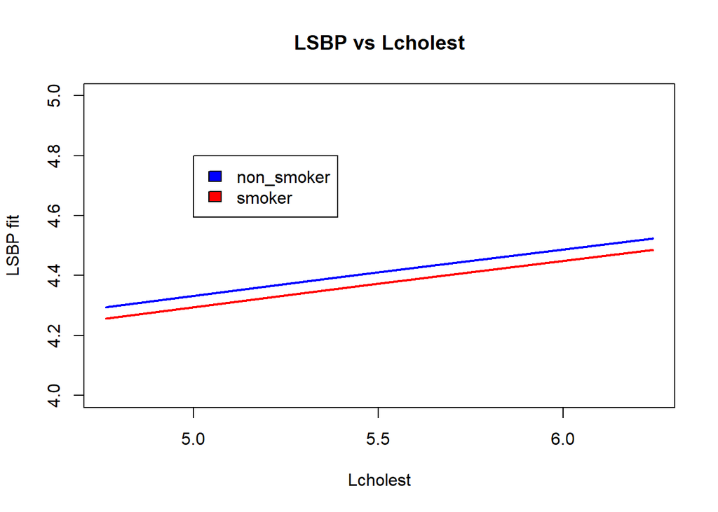

```r
Lcholest_val = seq(min(framingham$Lcholest) , max(framingham$Lcholest) , length = 10000)

LSBP_nonsmoker = predict(framingham.model.gam23 , newdata = data.frame("Lcholest" = Lcholest_val , "Smoker" = rep(0,10000 )) , se = T)
LSBP_smoker = predict(framingham.model.gam23 , newdata = data.frame("Lcholest" = Lcholest_val , "Smoker" = rep(1,10000 )) , se = T)

plot(framingham$Lcholest, framingham$LSBP,type="n",
     xlab="Lcholest",
     ylab="LSBP fit",
     main = "LSBP vs Lcholest",
     xlim = c(min(Lcholest_val) , max(Lcholest_val)),
     ylim = c(4.0 , 5.0))

lines(Lcholest_val , LSBP_nonsmoker$fit , type = "l" , col = "blue" , lwd = 2)
lines(Lcholest_val , LSBP_smoker$fit , type = "l" , col = "red", lwd = 2)
legend(5, 4.8, legend=c("non_smoker", "smoker"),fill = c("blue","red"))
```

### 7. In Question 5, display a plot of the two lines but in one graph with 2 columns, (par(mfrow(1,2) does this, I believe), and also show their pointwise 95% confidence intervals.

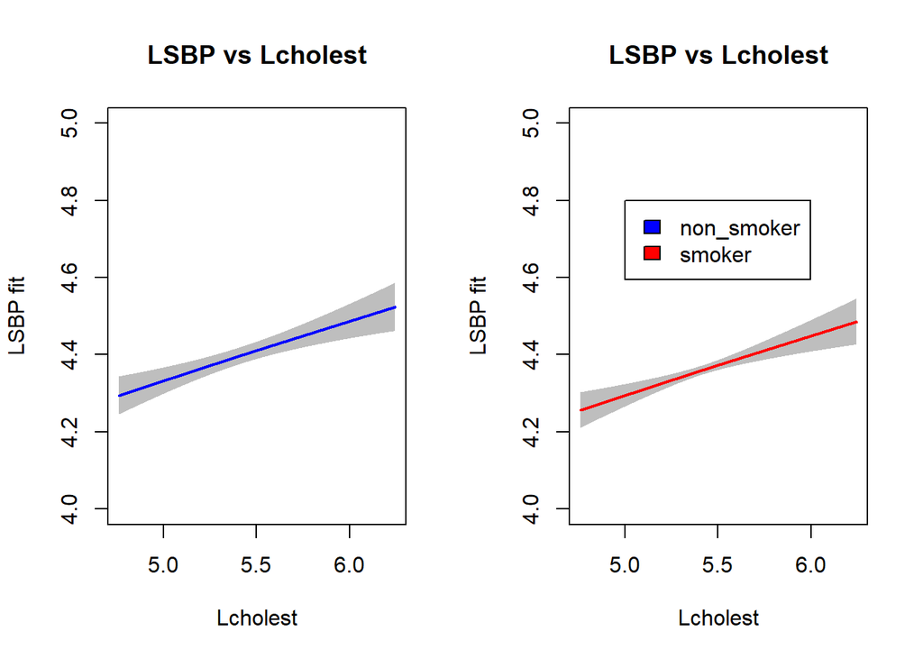

```r
par(mfrow = c(1,2))
plot(framingham$Lcholest, framingham$LSBP,type="n",
     xlab="Lcholest",
     ylab="LSBP fit",
     main = "LSBP vs Lcholest",
     xlim = c(min(Lcholest_val) , max(Lcholest_val)),
     ylim = c(4.0 , 5.0))

upper = LSBP_nonsmoker$fit + (1.96 * LSBP_nonsmoker$se.fit)
lower = LSBP_nonsmoker$fit - (1.96 * LSBP_nonsmoker$se.fit)
polygon(x=c(Lcholest_val, rev(Lcholest_val)), y=c(upper, rev(lower)),
        col="gray", border=NA)
lines(Lcholest_val , LSBP_nonsmoker$fit , type = "l" , col = "blue" , lwd = 2)

plot(framingham$Lcholest, framingham$LSBP,type="n",
     xlab="Lcholest",
     ylab="LSBP fit",
     main = "LSBP vs Lcholest",
     xlim = c(min(Lcholest_val) , max(Lcholest_val)),
     ylim = c(4.0 , 5.0))
upper = LSBP_smoker$fit + (1.96 * LSBP_smoker$se.fit)
lower = LSBP_smoker$fit - (1.96 * LSBP_smoker$se.fit)
polygon(x=c(Lcholest_val, rev(Lcholest_val)), y=c(upper, rev(lower)),
        col="gray", border=NA)
lines(Lcholest_val , LSBP_smoker$fit , type = "l" , col = "red", lwd = 2)
legend(5.0, 4.8, legend=c("non_smoker", "smoker"),fill = c("blue","red"))
```

### 8. Run the semiparametric version of ANCOVA but with an interaction. Does it look like there is an interaction? Cite p-values and estimates.

```r
library(mgcv)
#using K+2 to be consistent with our notation
framingham.model.gam23.int = mgcv::gam(LSBP ~ factor(Smoker)*Lcholest + s(Lcholest, k=25,bs="cr"), data=framingham, method="REML")
summary(framingham.model.gam23.int)
```

```
##
## Family: gaussian
## Link function: identity
##
## Formula:
## LSBP ~ factor(Smoker) * Lcholest + s(Lcholest, k = 25, bs = "cr")
##
## Parametric coefficients:
##                            Estimate Std. Error t value Pr(>|t|)
## (Intercept)               0.0000000  0.0000000     NaN      NaN
## factor(Smoker)1          -0.0327525  0.3891286  -0.084    0.933
## Lcholest                  0.8121215  0.0020324 399.592   <2e-16 ***
## factor(Smoker)1:Lcholest -0.0009682  0.0718498  -0.013    0.989
## ---
## Signif. codes:  0 '***' 0.001 '**' 0.01 '*' 0.05 '.' 0.1 ' ' 1
##
## Approximate significance of smooth terms:
##               edf Ref.df     F p-value
## s(Lcholest) 1.068  1.133 98.56  <2e-16 ***
## ---
## Signif. codes:  0 '***' 0.001 '**' 0.01 '*' 0.05 '.' 0.1 ' ' 1
##
## Rank: 27/28
## R-sq.(adj) =  0.0186   Deviance explained = 2.04%
## -REML = -210.83  Scale est. = 0.04443   n = 1615
```

Estimates and p-values are cited in the summary output. Smoker is no longer significant with p-value of 0.933. The interaction term is also not significant with p-value of 0.989. Therefore, does not look like there is an interaction.

### 9. In Question 8, display the fits but without the data points

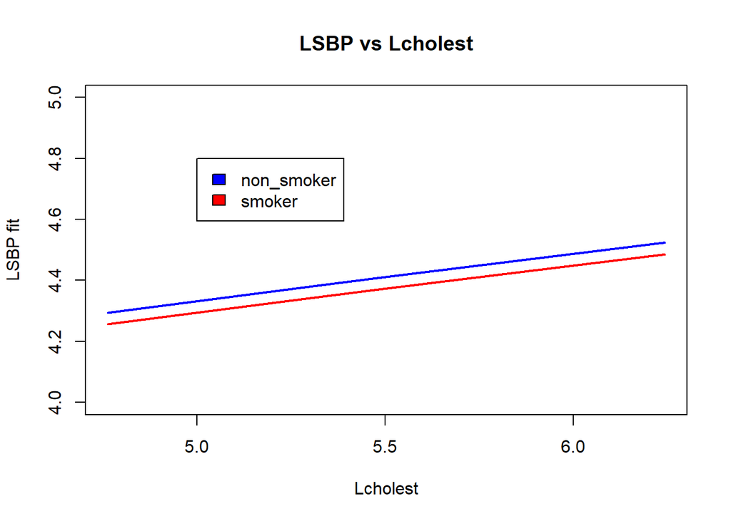

```r
Lcholest_val = seq(min(framingham$Lcholest) , max(framingham$Lcholest) , length = 10000)

LSBP_nonsmoker = predict(framingham.model.gam23.int , newdata = data.frame("Lcholest" = Lcholest_val , "Smoker" = as.factor(rep(0,10000 ))) , se = T)
LSBP_smoker = predict(framingham.model.gam23.int , newdata = data.frame("Lcholest" = Lcholest_val , "Smoker" = as.factor(rep(1,10000 ))) , se = T)

plot(framingham$Lcholest, framingham$LSBP,type="n",
     xlab="Lcholest",
     ylab="LSBP fit",
     main = "LSBP vs Lcholest",
     xlim = c(min(Lcholest_val) , max(Lcholest_val)),
     ylim = c(4.0 , 5.0))

lines(Lcholest_val , LSBP_nonsmoker$fit , type = "l" , col = "blue" , lwd = 2)
lines(Lcholest_val , LSBP_smoker$fit , type = "l" , col = "red", lwd = 2)
legend(5, 4.8, legend=c("non_smoker", "smoker"),fill = c("blue","red"))
```

### 10. What does having an interaction mean in the case when the factors are binary?

When there is an interaction and factors are binary, it means that the difference in mean response at two levels for one factor is not the same as that at two levels of the second factor. From lecture slides, a model with an interaction in the linear model just means fitting a different line for every factor level, but assuming equal regression error variances

### 11. Now run an analysis of whether the two lines (smoker versus nonsmoker) are statistically significantly different. You might remember that we contrasted the Srod district with the other Warsaw districts at one point.

```r
iSmoker = as.numeric(framingham$Smoker == 1)
inSmoker = as.numeric(framingham$Smoker == 0)
framingham.model.gam23.Smoker = gam (LSBP ~  s(Lcholest, iSmoker) , method = "REML" , data = framingham )
framingham.model.gam23.NSmoker = gam (LSBP ~  s(Lcholest, inSmoker) , method = "REML", data = framingham)
anova(framingham.model.gam23.Smoker, framingham.model.gam23.NSmoker, test = "F")
```

```
## Analysis of Deviance Table
##
## Model 1: LSBP ~ s(Lcholest, iSmoker)
## Model 2: LSBP ~ s(Lcholest, inSmoker)
##   Resid. Df Resid. Dev Df Deviance F Pr(>F)
## 1      1612     71.579
## 2      1612     71.579  0        0
```

```r
anova(framingham.model.gam23, framingham.model.gam23.int, test = "F")
```

```
## Analysis of Deviance Table
##
## Model 1: LSBP ~ Smoker + s(Lcholest, k = 25, bs = "cr")
## Model 2: LSBP ~ factor(Smoker) * Lcholest + s(Lcholest, k = 25, bs = "cr")
##   Resid. Df Resid. Dev     Df   Deviance      F Pr(>F)
## 1    1611.8     71.573
## 2    1610.8     71.573 1.0059 0.00021403 0.0048 0.9457
```

The second model isn’t statistically significantly better. So we can stick with the first one without interactions.